# meth02_minfi_pipeline

Epigenetics Bootcamp Summer 2024

`minfi` is one of the most commonly used R packages for working with Infinium Methylation BeadChips. In the following we import and preprocess the same dataset as in the first script but using `minfi`, and point out some differences to `ewastools`.

```r
options(warn=-1)
library(data.table)
library(magrittr)
options(warn=0)

pheno = fread("data/pheno_clean.csv")
```

Reminder: this is the `ewastools` pipeline (without QC)

```r
library(ewastools)

beta =
    paste0("data/", pheno$gsm) %>% # idat file paths
    read_idats(quiet=TRUE) %>%     # import fluorescence intensities
    detectionP %>%                 # compute detection p-values
    mask(0.01) %>%                 # set undetected probes to missing
    correct_dye_bias %>%
    dont_normalize                 # calculate beta-values
```

```
## [1] 1052641
```

```r
dim(beta)
```

```
## [1] 865918     30
```

There are some name collisions between `minfi` and `ewastools` (function definitions with the same name). We therefore detach `ewastools` (the inverse of `library()`), before we proceed.

```r
detach("package:ewastools")
```

In order to still be able to call functions from a package that is not loaded we can use the namespace operator `::`.  
The syntax is `package_name::function_name()`

## Pre-processing with `minfi`

```r
options(warn=-1)
suppressMessages(library(minfi))
suppressMessages(library(ENmix))
suppressMessages(library(IlluminaHumanMethylation450kmanifest))
suppressMessages(library(IlluminaHumanMethylation450kanno.ilmn12.hg19))
suppressMessages(library(IlluminaHumanMethylationEPICmanifest))
suppressMessages(library(IlluminaHumanMethylationEPICanno.ilm10b4.hg19))
suppressMessages(library(FlowSorted.Blood.450k))
suppressMessages(library(FlowSorted.Blood.EPIC))
options(warn=0)
idat_files = paste0("data/", pheno$gsm)
```

Importing idat files, result is a RGChannelSet

```r
rgset = read.metharray(basenames=idat_files)
rgset
```

```
## class: RGChannelSet
## dim: 1052641 30
## metadata(0):
## assays(2): Green Red
## rownames(1052641): 1600101 1600111 ... 99810990 99810992
## rowData names(0):
## colnames(30): GSM3229078 GSM3228657 ... GSM3229147 GSM3229108
## colData names(0):
## Annotation
##   array: IlluminaHumanMethylationEPIC
##   annotation: ilm10b4.hg19
```

`preprocessRaw` computes beta-value based on raw fluorescence intensities

```r
methylset = preprocessRaw(rgset)
methylset
```

```
## class: MethylSet
## dim: 866836 30
## metadata(0):
## assays(2): Meth Unmeth
## rownames(866836): cg18478105 cg09835024 ... cg10633746 cg12623625
## rowData names(0):
## colnames(30): GSM3229078 GSM3228657 ... GSM3229147 GSM3229108
## colData names(0):
## Annotation
##   array: IlluminaHumanMethylationEPIC
##   annotation: ilm10b4.hg19
## Preprocessing
##   Method: Raw (no normalization or bg correction)
##   minfi version: 1.44.0
##   Manifest version: 0.3.0
```

Many other preprocessing methods are available

- `preprocessNoob`: background subtraction/correction
- `preprocessFunnorm`: optionally includes preprocessNoob
- `preprocessIllumina`: normalization as in GenomeStudio software
- `preprocessQuantile`: quantile normalization stratified by U/M signal and probe type design
- `preprocessSWAN`: quantile normalization stratified by probe type design and number of CpG sites in probe sequence
- `preprocessENmix`: background correction (`ENmix` package)

```r
processed = preprocessIllumina(rgset[,1:2])
```

Due to their design, Type II probes feature more background noise, shifting the peaks for completely (un)methylated Cpg sites inwards

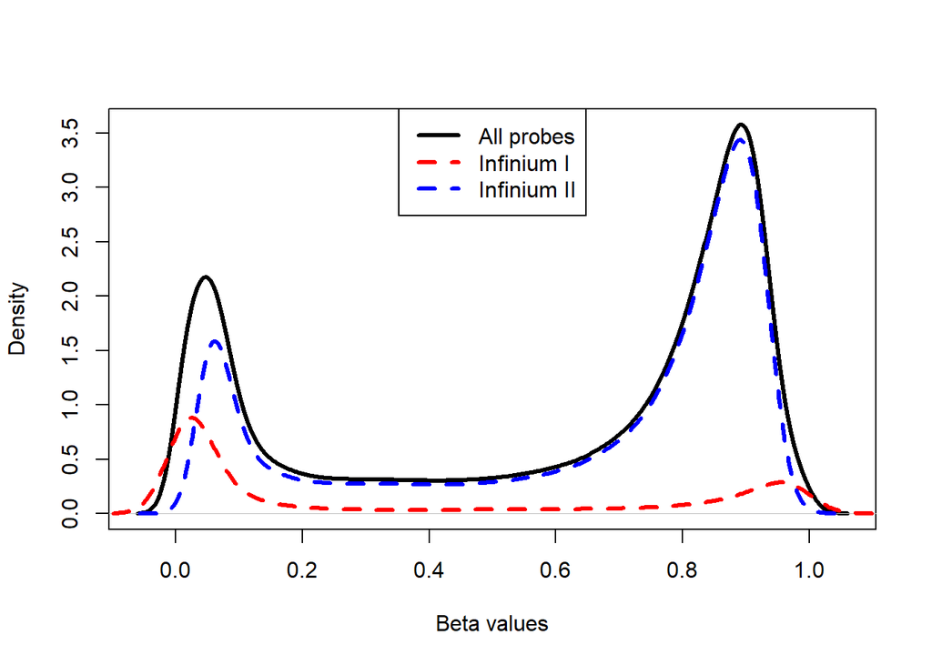

```r
plotBetasByType(getBeta(processed)[,1], probeTypes=getAnnotation(processed))
```

`rcp()` (regression on correlated probes) uses Type I probes to shift the distribution of beta-values of Type II probes. Compared to above plot, the peaks should be aligned now.

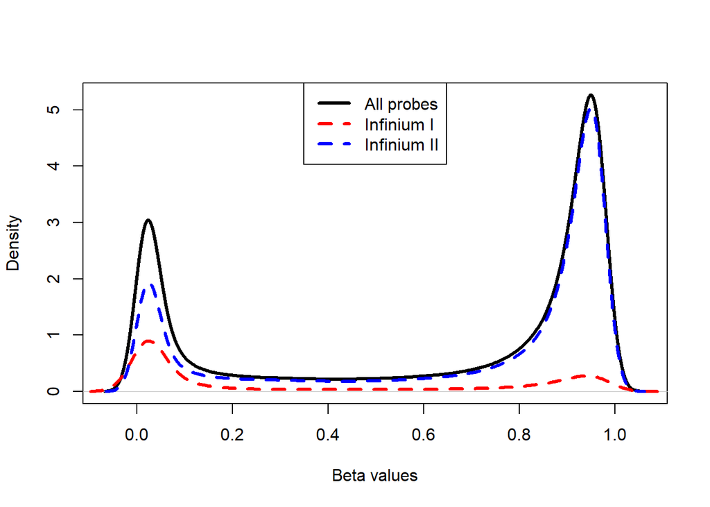

```r
plotBetasByType(    rcp(processed)[,1], probeTypes=getAnnotation(processed))
```

## Cell type prediction

```r
minfi.LC = estimateCellCounts2(rgset, compositeCellType="Blood")
```

```
## snapshotDate(): 2022-10-31
## snapshotDate(): 2022-10-31
```

```
## see ?FlowSorted.Blood.EPIC and browseVignettes('FlowSorted.Blood.EPIC') for documentation
```

```
## loading from cache
```

```
## [estimateCellCounts2] Combining user data with reference (flow sorted) data.
```

```
## [estimateCellCounts2] Processing user and reference data together.
```

```
## [estimateCellCounts2] Using IDOL L-DMR probes for composition estimation.
```

```
## [estimateCellCounts2] Estimating proportion composition (prop), if you provide cellcounts those will be provided as counts in the composition estimation.
```

```r
minfi.LC = minfi.LC$prop
```

**QUESTION:** What normalization is used by default?

**QUESTION:** Proportions for which cell types can be estimated when `compositeCellType=="CordBlood"`?

Comparison with `ewastools` shows that the estimates are not identical but highly correlated

```r
ewastools.LC = ewastools::estimateLC(beta, ref="Reinius")
```

```r
cor(ewastools.LC$CD4, minfi.LC[,"CD4T"] )
```

```
## [1] 0.9744136
```

```r
cor(ewastools.LC$GR , minfi.LC[,"Neu"] )
```

```
## [1] 0.9965904
```

```r
cor(ewastools.LC$MO , minfi.LC[,"Mono"] )
```

```
## [1] 0.9065723
```

```r
cor(ewastools.LC$B  , minfi.LC[,"Bcell"])
```

```
## [1] 0.9803785
```

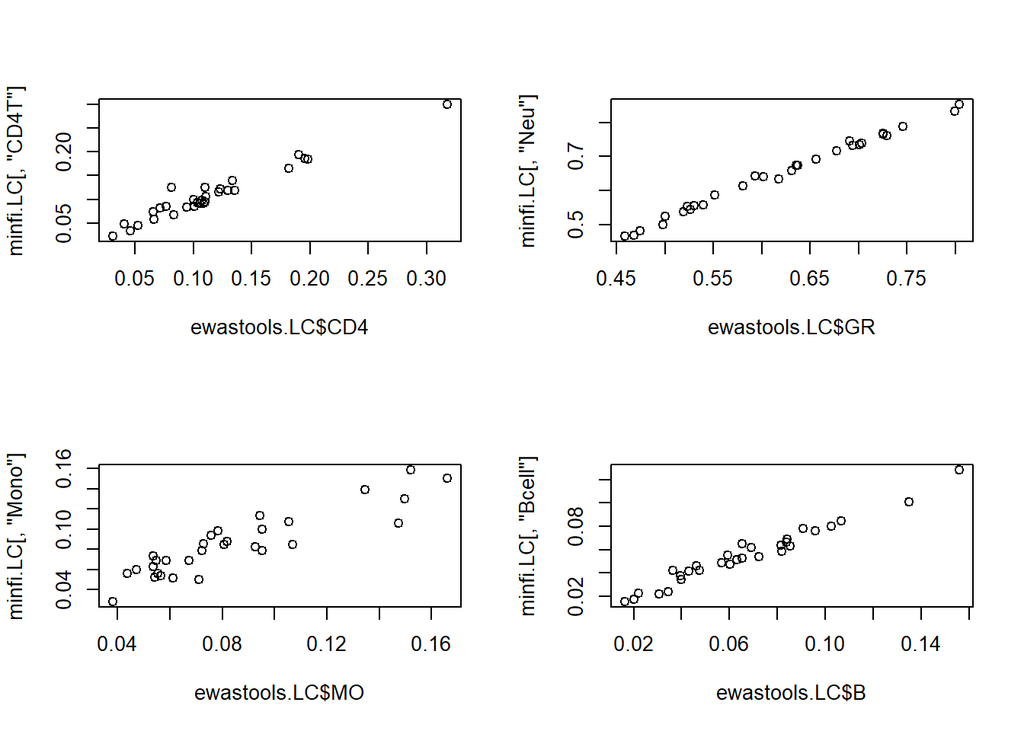

```r
par(mfrow = c(2, 2))
plot(ewastools.LC$CD4, minfi.LC[,"CD4T"])
plot(ewastools.LC$GR , minfi.LC[,"Neu"] )
plot(ewastools.LC$MO , minfi.LC[,"Mono"] )
plot(ewastools.LC$B  , minfi.LC[,"Bcell"])
```

```r
dev.off()
```

In case you have samples measured on both the 450K and EPIC chips, `minfi` can virtually convert them in both directions.

```r
convertArray(rgset, outType="IlluminaHumanMethylation450k")
```

```
## [convertArray] Casting as IlluminaHumanMethylation450k
```

```
## class: RGChannelSet
## dim: 575721 30
## metadata(0):
## assays(2): Green Red
## rownames(575721): 32735311 29674443 ... 28673402 13742412
## rowData names(0):
## colnames(30): GSM3229078 GSM3228657 ... GSM3229147 GSM3229108
## colData names(0):
## Annotation
##   array: IlluminaHumanMethylation450k
##   annotation: ilmn12.hg19
```

clear environment

```r
rm(list = ls()); gc()
```

```
##             used   (Mb) gc trigger   (Mb)   max used    (Mb)
## Ncells  18378023  981.5   30682738 1638.7   25283226  1350.3
## Vcells 240783698 1837.1 1171443502 8937.5 1429023512 10902.6
```